# Notebook Bart Vermeulen 2019

Oktober 2019

## SQL initialiseren

```r
#Onderstaande niet veranderen !
con <- DBI::dbConnect(RSQLite::SQLite(), ":memory:")


copy_to(con, mutate_at(df, vars(starts_with("datum")), as.character),
        "MijnTabel")

knitr::opts_chunk$set(connection = "con")
```

```sql
select *
from MijnTabel
```

# (SQL) 1. Welke verschillende producten zijn er verkocht in 2013?

```sql
SELECT
  DISTINCT Product
from
  MijnTabel
where Jaar = 2013
order by
  Product
```

Displaying records 1 - 10

| Product |
| --- |
| AWC Logo Cap |
| All-Purpose Bike Stand |
| Bike Wash - Dissolver |
| Classic Vest, L |
| Classic Vest, M |
| Classic Vest, S |
| Fender Set - Mountain |
| HL Mountain Tire |
| HL Road Tire |
| Half-Finger Gloves, L |

Hier kunnen we zien wat voor verschillende producten er verkocht zijn, dit betekent niet dat dit alleen de producten zijn wie we hebben (stel je hebt producten die nog niet verkocht zijn).

# (SQL) 2.Hoeveel verschillende leeftijden die een product hebben gekocht

```sql
select COUNT(DISTINCT leeftijd) as "Verschillende leeftijden klanten"
from MijnTabel
```

1 records

| Verschillende leeftijden klanten |
| --- |
| 70 |

Totaal hebben dus 70 verschillende leeftijden van klanten iets gekocht bij de groothandel.  
Dit kunnen dus allerlei producten zijn, niet alleen fietsen.

# (SQL) 3. Groote bereik van groothandel

```sql
select COUNT(DISTINCT Land) as "Hoeveelheid landen waar producten gekocht zijn."
from MIJNTABEL
```

1 records

| Hoeveelheid landen waar producten gekocht zijn. |
| --- |
| 6 |

Deze groothandel is dus niet alleen actief in 1 land maar in meerdere landen.  
Hieruit kunnen we dus opmaken dat deze groothandel een multinational is.

# (SQL) 4. Gemiddelde winst voor Accessoires

```sql
select ROUND(AVG(Winst), 2) as "Gemiddelde Winst"
from MijnTabel
where productcategorie = "Accessories"
```

1 records

| Gemiddelde Winst |
| --- |
| 126.39 |

Hierboven zien we de gemiddelde winst per bestelling voor Accessories in euro’s.

# (SQL) 5. Welke staten van landen worden er allemaal producten in verkocht?

```sql
select distinct staat, land
from MijnTabel
where staat is not null
order by
land
```

Displaying records 1 - 10

| Staat | Land |
| --- | --- |
| New South Wales | Australia |
| Victoria | Australia |
| Queensland | Australia |
| South Australia | Australia |
| Tasmania | Australia |
| British Columbia | Canada |
| Alberta | Canada |
| Ontario | Canada |
| Seine Saint Denis | France |
| Moselle | France |

We hadden al gekeken in hoeveel landen de groothandel actief was, maar hier kijken we in welke landen en staten de groothandel actief is.

```sql
select distinct KlantID, Leeftijd
from MijnTabel
```

# (GGPLOT2) 1. Leeftijden van klanten

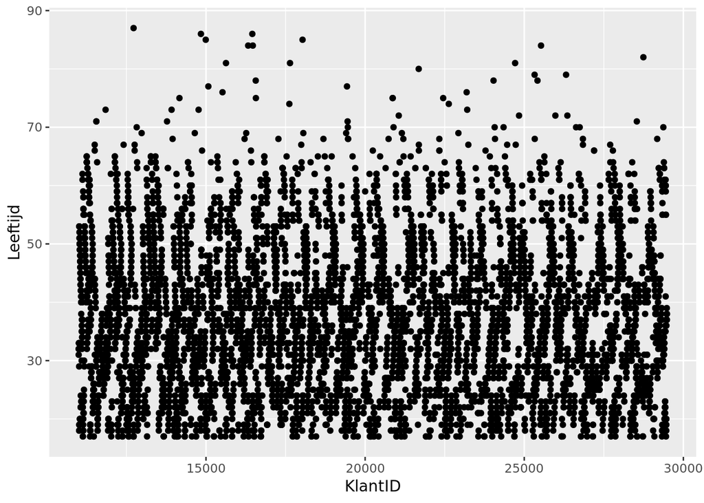

```r
ggplot(ggplot1, aes(KlantID, Leeftijd)) +
  geom_point()
```

# (GGPLOT2) 2. Leeftijd van klanten die producten hebben gekocht

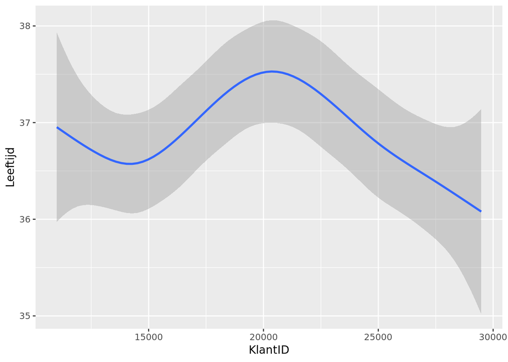

```r
ggplot(ggplot1, aes(KlantID, Leeftijd)) +
  geom_smooth()
```

Hier zien we de leeftijden van onze klanten in een gemiddelde lijn en de uitloop.

# (GGPLOT2) 3. De opbrengst ten opzichten van de kosten

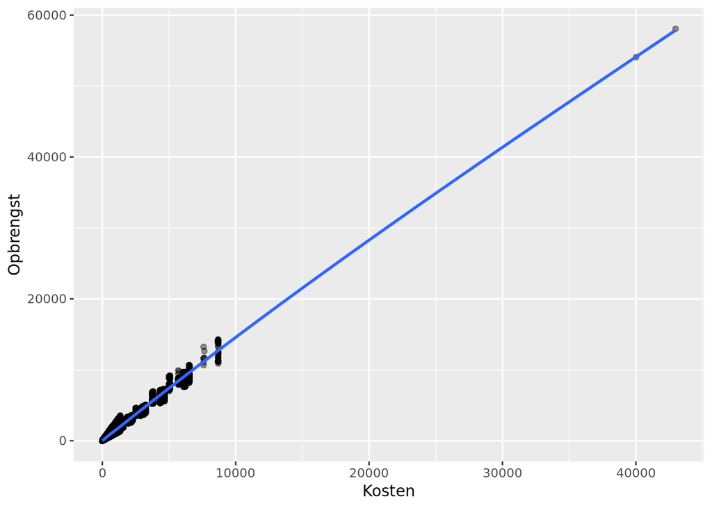

```r
ggplot(df_result, aes(Kosten, Opbrengst)) +
  geom_point(alpha = 0.4) +
  geom_smooth()
```

# (GGPLOT2) 4. De opbrengst ten opzichten van de kosten per categorie

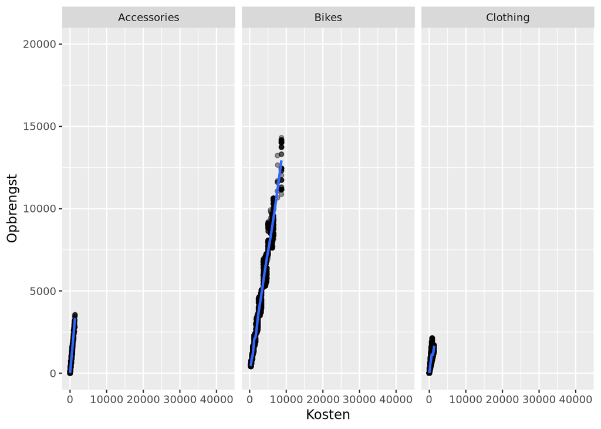

```r
ggplot(df_result, aes(x = Kosten, y = Opbrengst)) +
  geom_point(alpha = 0.4) +
  geom_smooth() +
  facet_grid(. ~ ProductCategorie) +
  scale_y_continuous(limits = c(0,20000))
```

Hier hebben we bijna hetzelfde als bij nummer 3 alleen kijken we nu per categorie.

```sql
select distinct KlantID, Winst
from MijnTabel
```

# (GGPLOT2) 5.De winst per klant

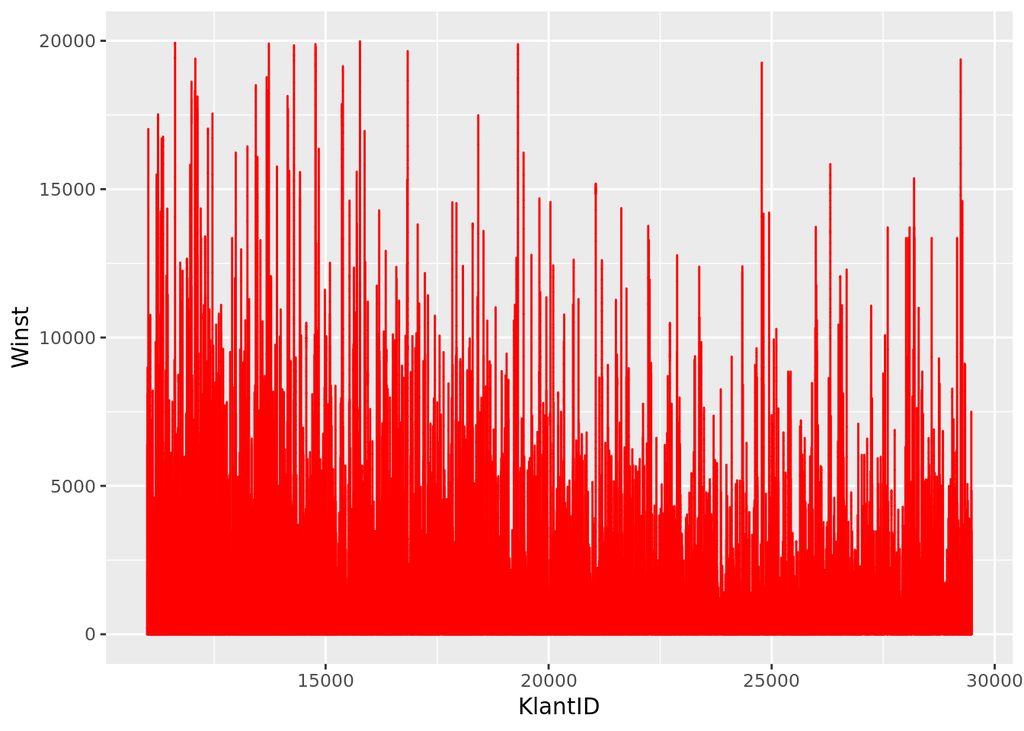

```r
ggplot(ggplot5, aes(KlantID, Winst)) +
  geom_col(color = "red") +
  scale_y_continuous(limits = c(0,20000))
```

Eigenlijk wat we nu hier zien is de winst die we per klant in totaal hebben gemaakt.

# (TidyVerse) 1.Meeste winst per bestelling

```r
df_result %>%
  arrange(desc(Winst)) %>%
  head(20)
```

```
##         Datum     Maand Jaar KlantID Leeftijd             AgeGroup
## 1  2015-07-24      juli 2015   11025       52       Adults (35-64)
## 2  2013-07-24      juli 2013   11025       52       Adults (35-64)
## 3  2011-01-15   januari 2011   25978       72        Seniors (64+)
## 4  2011-07-08      juli 2011   28766       22          Youth (<25)
## 5  2011-03-20     maart 2011   14772       29 Young Adults (25-34)
## 6  2011-07-05      juli 2011   24778       26 Young Adults (25-34)
## 7  2011-04-30     april 2011   27602       44       Adults (35-64)
## 8  2011-05-12       mei 2011   28092       19          Youth (<25)
## 9  2011-09-30 september 2011   28092       19          Youth (<25)
## 10 2011-07-17      juli 2011   28176       30 Young Adults (25-34)
## 11 2011-02-11  februari 2011   28198       39       Adults (35-64)
## 12 2011-03-29     maart 2011   11324       58       Adults (35-64)
## 13 2011-03-24     maart 2011   11625       24          Youth (<25)
## 14 2011-03-27     maart 2011   11625       24          Youth (<25)
```

[output cut: 69 more lines]

Hierboven wordt de top 20 bestellingen getoont met de meeste winst.

# (TidyVerse) 2.Meeste winst op fietsen

```r
df_result %>%
  filter(ProductCategorie == "Bikes") %>%
  arrange(desc(Winst)) %>%
  head(20)
```

```
##         Datum     Maand Jaar KlantID Leeftijd             AgeGroup
## 1  2011-01-15   januari 2011   25978       72        Seniors (64+)
## 2  2011-07-08      juli 2011   28766       22          Youth (<25)
## 3  2011-03-20     maart 2011   14772       29 Young Adults (25-34)
## 4  2011-07-05      juli 2011   24778       26 Young Adults (25-34)
## 5  2011-04-30     april 2011   27602       44       Adults (35-64)
## 6  2011-05-12       mei 2011   28092       19          Youth (<25)
## 7  2011-09-30 september 2011   28092       19          Youth (<25)
## 8  2011-07-17      juli 2011   28176       30 Young Adults (25-34)
## 9  2011-02-11  februari 2011   28198       39       Adults (35-64)
## 10 2011-03-29     maart 2011   11324       58       Adults (35-64)
## 11 2011-03-24     maart 2011   11625       24          Youth (<25)
## 12 2011-03-27     maart 2011   11625       24          Youth (<25)
## 13 2011-08-08  augustus 2011   12079       52       Adults (35-64)
## 14 2011-12-05  december 2011   12200       60       Adults (35-64)
```

[output cut: 69 more lines]

Hierboven hebben we de top 20 fiets bestellingen met de meeste winst

# (TidyVerse) 3. Gemiddelde winst per unit

```r
df_result %>%
  mutate(GemWinstPerUnit = Winst / OrderAantal) %>%
  head(20)
```

```
##         Datum     Maand Jaar KlantID Leeftijd             AgeGroup
## 1  2013-11-26  november 2013   11019       19          Youth (<25)
## 2  2015-11-26  november 2015   11019       19          Youth (<25)
## 3  2014-03-23     maart 2014   11039       49       Adults (35-64)
## 4  2016-03-23     maart 2016   11039       49       Adults (35-64)
## 5  2014-05-15       mei 2014   11046       47       Adults (35-64)
## 6  2016-05-15       mei 2016   11046       47       Adults (35-64)
## 7  2014-05-22       mei 2014   11047       47       Adults (35-64)
## 8  2016-05-22       mei 2016   11047       47       Adults (35-64)
## 9  2014-02-22  februari 2014   11094       35       Adults (35-64)
## 10 2016-02-22  februari 2016   11094       35       Adults (35-64)
## 11 2013-07-30      juli 2013   11101       32 Young Adults (25-34)
## 12 2015-07-30      juli 2015   11101       32 Young Adults (25-34)
## 13 2013-07-15      juli 2013   11109       34 Young Adults (25-34)
## 14 2015-07-15      juli 2015   11109       34 Young Adults (25-34)
```

[output cut: 69 more lines]

Hierboven wordt ook de gemiddelde winst per unit in een bestelling berekent.

# (TidyVerse) 4.Gemiddelde winst per unit bij fietsen

```r
df_result %>%
  filter(ProductCategorie == "Bikes") %>%
  mutate(GemWinstPerUnit = Winst / OrderAantal) %>%
  head(20)
```

```
##         Datum    Maand Jaar KlantID Leeftijd             AgeGroup
## 1  2013-01-28  januari 2013   11000       31 Young Adults (25-34)
## 2  2015-01-28  januari 2015   11000       31 Young Adults (25-34)
## 3  2013-07-22     juli 2013   11000       31 Young Adults (25-34)
## 4  2015-07-22     juli 2015   11000       31 Young Adults (25-34)
## 5  2013-12-25 december 2013   11000       31 Young Adults (25-34)
## 6  2015-12-25 december 2015   11000       31 Young Adults (25-34)
## 7  2014-02-13 februari 2014   11000       31 Young Adults (25-34)
## 8  2016-02-13 februari 2016   11000       31 Young Adults (25-34)
## 9  2013-07-04     juli 2013   11002       32 Young Adults (25-34)
## 10 2015-07-04     juli 2015   11002       32 Young Adults (25-34)
## 11 2013-02-07 februari 2013   11005       32 Young Adults (25-34)
## 12 2015-02-07 februari 2015   11005       32 Young Adults (25-34)
## 13 2013-07-27     juli 2013   11005       32 Young Adults (25-34)
## 14 2015-07-27     juli 2015   11005       32 Young Adults (25-34)
```

[output cut: 69 more lines]

Hierboven wordt ook de gemiddelde winst per unit in een bestelling waar fietsen zijn bestelt berekent.

# (TidyVerse) 5.Meeste winst per unit in juli 2015

```r
df_result %>%
  filter(Maand == "juli", Jaar == 2015) %>%
  mutate(GemWinstPerUnit = Winst / OrderAantal) %>%
  arrange(desc(GemWinstPerUnit)) %>%
  head(20)
```

```
##         Datum Maand Jaar KlantID Leeftijd             AgeGroup
## 1  2015-07-08  juli 2015   11335       36       Adults (35-64)
## 2  2015-07-22  juli 2015   25910       18          Youth (<25)
## 3  2015-07-01  juli 2015   23859       29 Young Adults (25-34)
## 4  2015-07-26  juli 2015   13257       40       Adults (35-64)
## 5  2015-07-05  juli 2015   22785       45       Adults (35-64)
## 6  2015-07-07  juli 2015   23281       40       Adults (35-64)
## 7  2015-07-04  juli 2015   23859       29 Young Adults (25-34)
## 8  2015-07-29  juli 2015   24661       50       Adults (35-64)
## 9  2015-07-16  juli 2015   11243       40       Adults (35-64)
## 10 2015-07-24  juli 2015   11243       40       Adults (35-64)
## 11 2015-07-07  juli 2015   11341       61       Adults (35-64)
## 12 2015-07-23  juli 2015   11337       36       Adults (35-64)
## 13 2015-07-23  juli 2015   28643       26 Young Adults (25-34)
## 14 2015-07-02  juli 2015   21746       35       Adults (35-64)
```

[output cut: 69 more lines]

De 20 beste winst bestellingen in juli 2015.

# (TidyVerse) 6.Meeste winst bij vrouwen

```r
df_result %>%
  filter(KlantGeslacht == "F") %>%
  arrange(desc(Winst)) %>%
  head(20)
```

```
##         Datum     Maand Jaar KlantID Leeftijd             AgeGroup
## 1  2011-01-15   januari 2011   25978       72        Seniors (64+)
## 2  2011-03-20     maart 2011   14772       29 Young Adults (25-34)
## 3  2011-05-12       mei 2011   28092       19          Youth (<25)
## 4  2011-09-30 september 2011   28092       19          Youth (<25)
## 5  2011-07-17      juli 2011   28176       30 Young Adults (25-34)
## 6  2011-06-19      juni 2011   12209       57       Adults (35-64)
## 7  2011-09-02 september 2011   28014       53       Adults (35-64)
## 8  2011-01-03   januari 2011   28200       39       Adults (35-64)
## 9  2011-01-31   januari 2011   29264       61       Adults (35-64)
## 10 2011-01-17   januari 2011   29275       44       Adults (35-64)
## 11 2011-08-26  augustus 2011   13689       24          Youth (<25)
## 12 2011-08-20  augustus 2011   14778       30 Young Adults (25-34)
## 13 2011-01-21   januari 2011   29476       38       Adults (35-64)
## 14 2011-12-14  december 2011   14801       33 Young Adults (25-34)
```

[output cut: 69 more lines]

De meeste winst bij bestellingen geplaats door een vrouw.